# Data Exploration Assignment Analysis

Kimberly Nguyen

2022-05-19

df$UGDS <- as.numeric(as.character(df$UGDS)) test <- feols(fml = UGDS ~ index, data = df) etable(test)

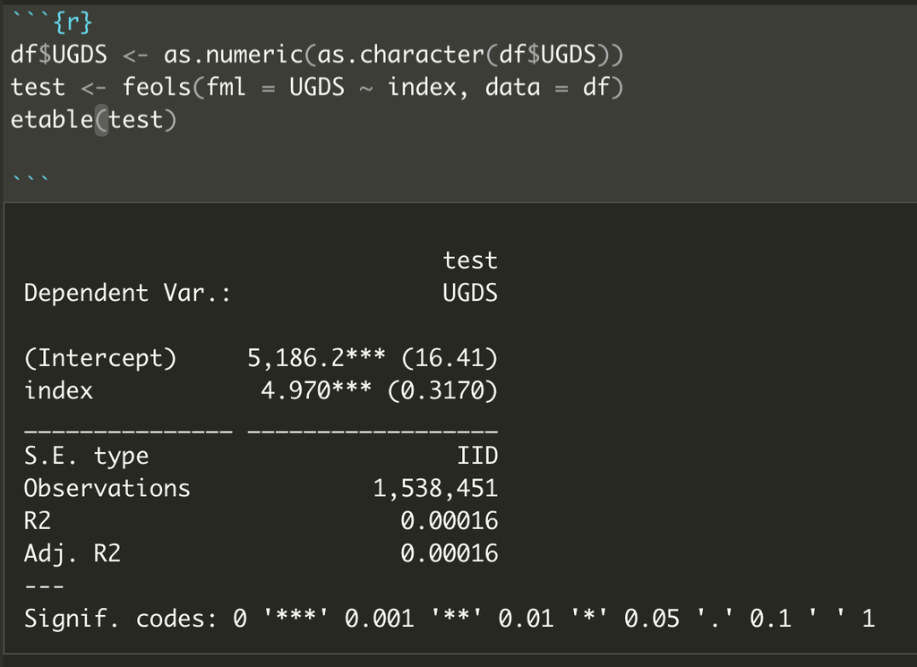

etable results

r1 <- df %>% filter((str_sub(monthorweek, start = 1, end = 4) < “2015”)) %>% filter(PREDDEG == 3) %>% group_by(pct10_earn_wne_p10) %>% feols(fml = ADM_RATE ~ index, data = df)

r2 <- r1 <- df %>% filter((str_sub(monthorweek, start = 1, end = 4) < “2015”)) %>% filter(PREDDEG == 3) %>% group_by(pct90_earn_wne_p10) %>% feols(fml = ADM_RATE ~ index, data = df)

r3 <- df %>% filter((str_sub(monthorweek, start = 1, end = 4) > “2015”)) %>% filter(PREDDEG == 3) %>% group_by(pct10_earn_wne_p10) %>% feols(fml = ADM_RATE ~ index, data = df)

r4 <- r1 <- df %>% filter((str_sub(monthorweek, start = 1, end = 4) > “2015”)) %>% filter(PREDDEG == 3) %>% group_by(pct90_earn_wne_p10) %>% feols(fml = ADM_RATE ~ index, data = df)

An 1 unit increase in index is associated with a 4.970 increase in UGDS.

Since the research question asks if the release of the Scorecard shift student interest to high-earnings colleges relative to low-earning ones, my analysis would address admission rates in both high-earnings colleges and low-earnings colleges before and after 2015/Scorecard’s release. If admission rates go up after 2015, it would be associated with the release of Scorecard. Using controls and wald() would also produce values to tests check values on wether to reject or fail to reject the hypothesizes.